# K-Means

# Tarea 4.

# Ejercicios

Librerias

```r
library('GGally')
```

```r
library('ggplot2')

library('visdat')

library('dplyr')
library('data.table')
library('reshape')
library('cluster')

library('factoextra')
```

## 1. Desarolle el Análisis del Problema

### Análisis del Problema

Realizar un análisis exploratorio de los datos para posterior a esto evaluar la agrupación de los datos mediante un modelo no supervisando utilizando Kmeans.

Detalle de los datos:

1. Fresh: Gasto anual (m.u.) en productos frescos (Continuo)
2. Milk: Gasto anual (m.u.) en productos lácteos (Continuo);
3. Grocery: Gasto anual (m.u.) en productos comestibles (Continuo);
4. Frozen: Gasto anual (m.u.) en productos congelados (Continuo)
5. Detergents_Paper: Gasto anual (m.u.) en detergentes y productos de papel (Continuo)
6. Delicatessen: Gasto anual (m.u.) en productos exóticos (Continuous);
7. Channel: Canal de clientes => Horeca (Hotel/Restaurante/Cafê) ó Retail (Nominal)
8. Region: Canal de region - Lisbon, Oporto u Other (Nominal)

Fuente del dataset: https://archive.ics.uci.edu/ml/datasets/Wholesale+customers

## 2. Cargue el archivo Wholesale customers data.csv en una variable

```r
# Carga de datos
wholesale_data <- read.csv('Wholesale.csv', header = T, na.strings = '?')

# Datos sin variables nominales (Channel & Region)
wholesale_data_clean <- wholesale_data[,c(3: 8)]
```

## 3. Desarolle el Entendimiento de los Datos

```r
# Resultado de los datos
# Valores mínimos, máximos, mediana y media de cada columna
summary(wholesale_data)
```

```
##     Channel          Region          Fresh             Milk
##  Min.   :1.000   Min.   :1.000   Min.   :     3   Min.   :   55
##  1st Qu.:1.000   1st Qu.:2.000   1st Qu.:  3128   1st Qu.: 1533
##  Median :1.000   Median :3.000   Median :  8504   Median : 3627
##  Mean   :1.323   Mean   :2.543   Mean   : 12000   Mean   : 5796
##  3rd Qu.:2.000   3rd Qu.:3.000   3rd Qu.: 16934   3rd Qu.: 7190
##  Max.   :2.000   Max.   :3.000   Max.   :112151   Max.   :73498
##     Grocery          Frozen        Detergents_Paper    Delicassen
##  Min.   :    3   Min.   :   25.0   Min.   :    3.0   Min.   :    3.0
##  1st Qu.: 2153   1st Qu.:  742.2   1st Qu.:  256.8   1st Qu.:  408.2
##  Median : 4756   Median : 1526.0   Median :  816.5   Median :  965.5
##  Mean   : 7951   Mean   : 3071.9   Mean   : 2881.5   Mean   : 1524.9
##  3rd Qu.:10656   3rd Qu.: 3554.2   3rd Qu.: 3922.0   3rd Qu.: 1820.2
##  Max.   :92780   Max.   :60869.0   Max.   :40827.0   Max.   :47943.0
```

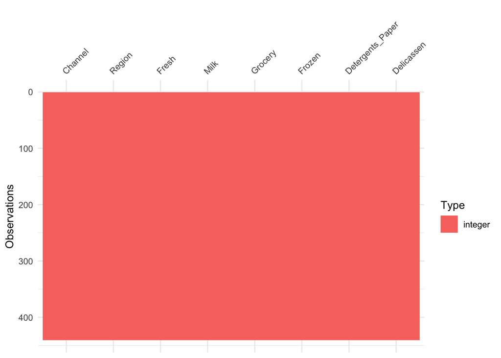

```r
# Visualización de tipos de datos
vis_dat(wholesale_data)
```

```r
# Numero de filas del dataset
nrow(wholesale_data)
```

```
## [1] 440
```

```r
# Revisar valores nulos del dataset
sum(is.na(wholesale_data))
```

```
## [1] 0
```

### Resultado breve de los datos

- Numero de registros: 440
- Registros valores nulos: 0
- Tipos de datos encontrados: Números enteros
- Numero de columnas o variables encontradas: 8 (6 variables cuantitativas continuas & 2 variables cualitativas nominales)

## 4. Utilizando barplot cree un gráfico de los atributos del dataset, observe las correlaciones entre atributos

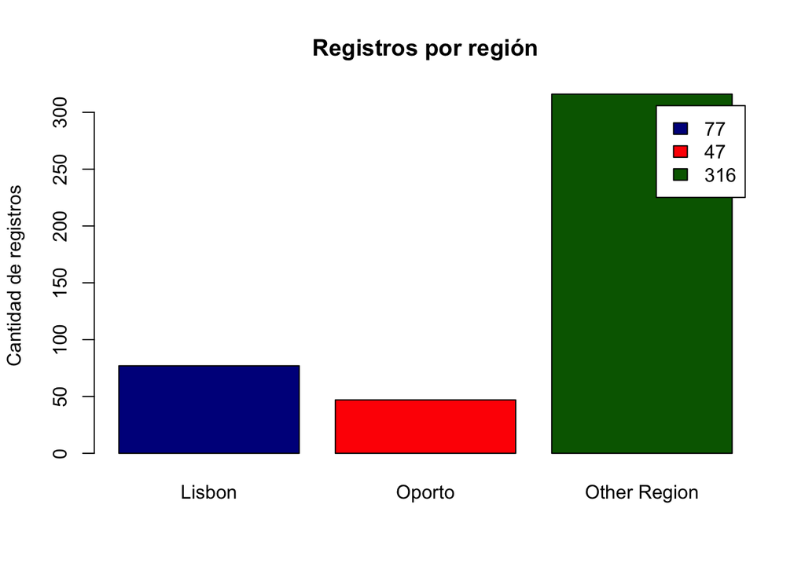

```r
# Cantidad de registros por región
region_counts <- table(wholesale_data["Region"])

# Cantidad de registros por canal
channel_counts <- table(wholesale_data["Channel"])


# Registros por región
barplot(table(
        wholesale_data["Region"]),
        main="Registros por región",
        names.arg = c("Lisbon", "Oporto", "Other Region"),
        ylab = "Cantidad de registros",
        col=c("darkblue","red", "darkgreen"),
        legend = region_counts)
```

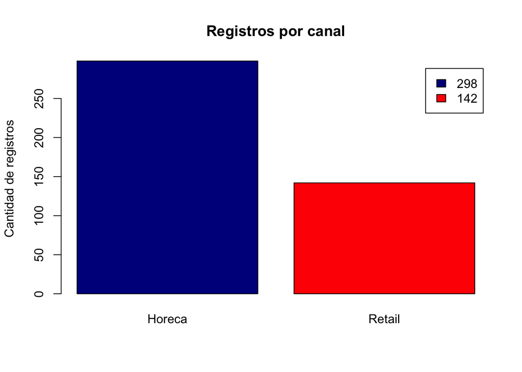

```r
# Registros por canal
barplot(table(
        wholesale_data["Channel"]),
        main = "Registros por canal",
        names.arg   = c("Horeca", "Retail"),
        ylab = "Cantidad de registros",
        col=c("darkblue","red"),
        legend = channel_counts)
```

### Resultado breve de los datos:

Cantidad por región:

- Lisbon: 77
- Oporto: 47
- Other Region: 316

Cantidad por canal:

- Horeca: 298
- Retail: 142

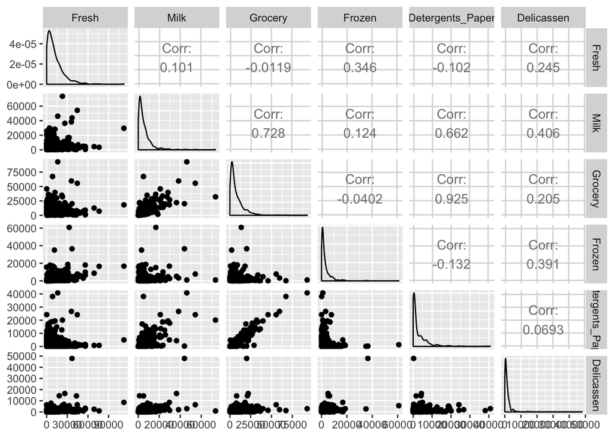

```r
# Gráfico de correlaciones entre atributos, se ignoran Channel y Region como parte del proceso de análisis ya que son variables cualitativas nominales
ggpairs(wholesale_data_clean)
```

### Interpretando los resultados de la correlación

#### Tipos de relación

- -1,00 = Correlación negativa perfecta
- -0,90 = Correlación negativa muy fuerte
- -0,75 = Correlación negativa considerable
- -0,50 = Correlación negativa media
- -0,10 = Correlación negativa débil
- 0,00 = No existe correlación lineal alguna entre las variables
- 0,10 = Correlación positiva débil
- 0,50 = Correlación positiva media
- 0,75 = Correlación positiva considerable
- 0,90 = Correlación positiva muy fuerte
- 1,00 = Correlación positiva perfecta

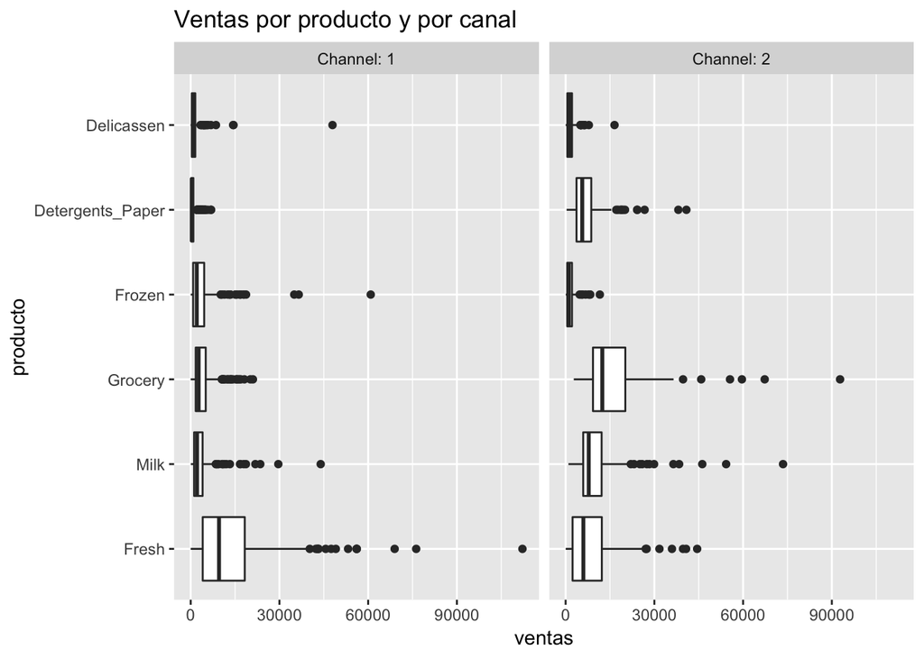

```r
#Grafico
# Es necesario agregar id.vars con Region & Channel para poder dividir los datos
bxplt <- ggplot(data = melt(wholesale_data, id.vars=c('Region','Channel'), variable.name = c("AgeGroup", "Geo")), aes(x= variable, y = value))
bxplt <- bxplt + geom_boxplot()
bxplt <- bxplt + facet_wrap(~Channel,labeller = "label_both")
bxplt <- bxplt + coord_flip()
bxplt <- bxplt + labs(x = 'producto', y  = 'ventas')
bxplt <- bxplt + ggtitle('Ventas por producto y por canal')
bxplt
```

## 6. Cree un modelo de agrupación K- Means

Para agrupar a los clientes con base al consumo, vamos a utilizar solo las variables Fresh, Milk, Grocery, Frozen, Detergents_Paper y Delicassen. En este caso, vamos a intentar agrupar los clientes en 5 grupos diferentes.

### Modelo con 5 centroides

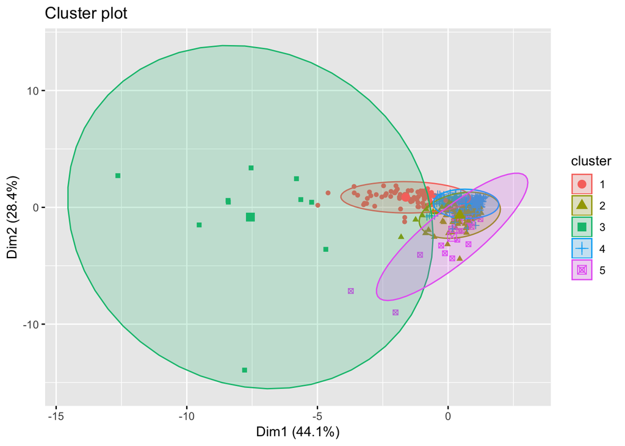

```r
set.seed(123)

# Centroides utilizando k-means
modelo_kmeans_5 <- kmeans(wholesale_data_clean, centers = 5)

# Predecir utilizando el modelo para agregar una variable nueva llamada 'cluster' al conjunto de datos
wholesale_data$cluster5 <- modelo_kmeans_5$cluster

# Convertir la variable nueva a un factor
wholesale_data$cluster5 <- factor(wholesale_data$cluster5)

# Visualización de clusters
fviz_cluster(modelo_kmeans_5, wholesale_data_clean, geom = "point", ellipse.type = "norm")
```

## 6. Realice al menos 3 modelos cambiando los centroides

### Modelo con 6 centroides

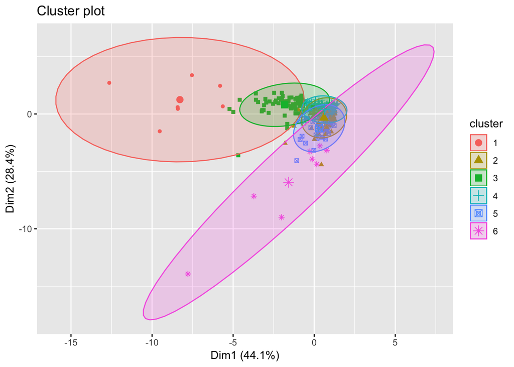

```r
# Centroides utilizando k-means
modelo_kmeans_6 <- kmeans(wholesale_data_clean, centers = 6)

# Predecir utilizando el modelo para agregar una variable nueva llamada 'cluster' al conjunto de datos
wholesale_data$cluster6 <- modelo_kmeans_6$cluster

# Convertir la variable nueva a un factor
wholesale_data$cluster6 <- factor(wholesale_data$cluster6)

# Visualización de clusters
fviz_cluster(modelo_kmeans_6, wholesale_data_clean, geom = "point", ellipse.type = "norm")
```

### Modelo con 7 centroides

```
## Too few points to calculate an ellipse
```

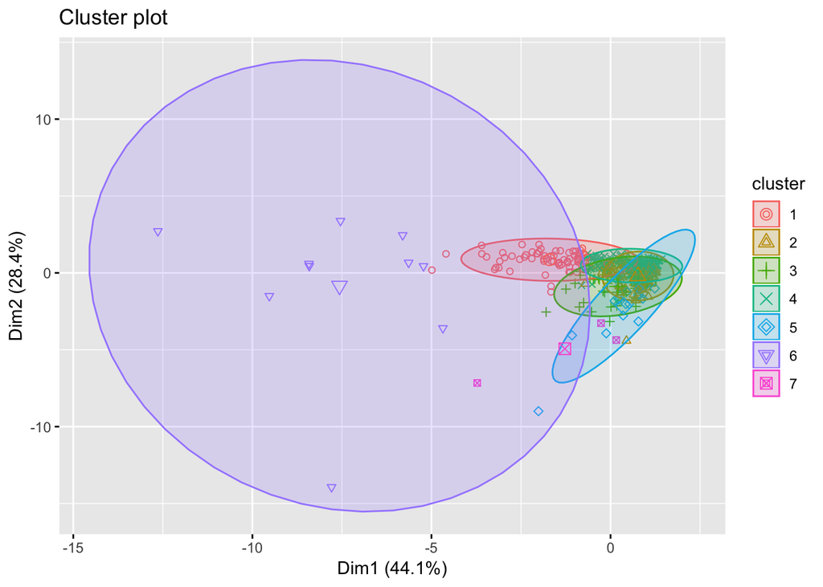

```r
# Centroides utilizando k-means
modelo_kmeans_7 <- kmeans(wholesale_data_clean, centers = 7)

# Predecir utilizando el modelo para agregar una variable nueva llamada 'cluster' al conjunto de datos
wholesale_data$cluster7 <- modelo_kmeans_7$cluster

# Convertir la variable nueva a un factor
wholesale_data$cluster7 <- factor(wholesale_data$cluster7)

# Visualización de clusters
fviz_cluster(modelo_kmeans_7, wholesale_data_clean, geom = "point", ellipse.type = "norm")
```

## 7. Evaluación del modelo

```r
# Evaluación del modelo "modelo_kmeans_5" que posee 5 grupos

# Gasto total del producto Milk por grupo
by(wholesale_data$Milk,  modelo_kmeans_5$cluster, sum)
```

```
## modelo_kmeans_5$cluster: 1
## [1] 919489
## --------------------------------------------------------
## modelo_kmeans_5$cluster: 2
## [1] 401253
## --------------------------------------------------------
## modelo_kmeans_5$cluster: 3
## [1] 374433
## --------------------------------------------------------
## modelo_kmeans_5$cluster: 4
## [1] 740555
## --------------------------------------------------------
## modelo_kmeans_5$cluster: 5
## [1] 114627
```

```r
# Gasto total del producto Fresh por grupo
by(wholesale_data$Fresh,  modelo_kmeans_5$cluster, sum)
```

```
## modelo_kmeans_5$cluster: 1
## [1] 368739
## --------------------------------------------------------
## modelo_kmeans_5$cluster: 2
## [1] 2176430
## --------------------------------------------------------
## modelo_kmeans_5$cluster: 3
## [1] 212637
## --------------------------------------------------------
## modelo_kmeans_5$cluster: 4
## [1] 1388515
## --------------------------------------------------------
## modelo_kmeans_5$cluster: 5
## [1] 1133810
```

```r
# Gasto total del producto Grocery por grupo
by(wholesale_data$Grocery,  modelo_kmeans_5$cluster, sum)
```

```
## modelo_kmeans_5$cluster: 1
## [1] 1444893
## --------------------------------------------------------
## modelo_kmeans_5$cluster: 2
## [1] 527959
## --------------------------------------------------------
## modelo_kmeans_5$cluster: 3
## [1] 467106
## --------------------------------------------------------
## modelo_kmeans_5$cluster: 4
## [1] 930027
## --------------------------------------------------------
## modelo_kmeans_5$cluster: 5
## [1] 128577
```

```r
# Gasto total del producto Frozen por grupo
by(wholesale_data$Frozen,  modelo_kmeans_5$cluster, sum)
```

```
## modelo_kmeans_5$cluster: 1
## [1] 120494
## --------------------------------------------------------
## modelo_kmeans_5$cluster: 2
## [1] 426644
## --------------------------------------------------------
## modelo_kmeans_5$cluster: 3
## [1] 62872
## --------------------------------------------------------
## modelo_kmeans_5$cluster: 4
## [1] 551067
## --------------------------------------------------------
## modelo_kmeans_5$cluster: 5
## [1] 190573
```

```r
# Gasto total del producto Detergents_Paper por grupo
by(wholesale_data$Detergents_Paper,  modelo_kmeans_5$cluster, sum)
```

```
## modelo_kmeans_5$cluster: 1
## [1] 636765
## --------------------------------------------------------
## modelo_kmeans_5$cluster: 2
## [1] 116087
## --------------------------------------------------------
## modelo_kmeans_5$cluster: 3
## [1] 216994
## --------------------------------------------------------
## modelo_kmeans_5$cluster: 4
## [1] 275879
## --------------------------------------------------------
## modelo_kmeans_5$cluster: 5
## [1] 22132
```

```r
# Gasto total del producto Delicassen por grupo
by(wholesale_data$Delicassen,  modelo_kmeans_5$cluster, sum)
```

```
## modelo_kmeans_5$cluster: 1
## [1] 125962
## --------------------------------------------------------
## modelo_kmeans_5$cluster: 2
## [1] 174729
## --------------------------------------------------------
## modelo_kmeans_5$cluster: 3
## [1] 87433
## --------------------------------------------------------
## modelo_kmeans_5$cluster: 4
## [1] 224314
## --------------------------------------------------------
## modelo_kmeans_5$cluster: 5
## [1] 58505
```

```r
# Cantidad de gastos en productos por canal (1 - Horeca, 2- Retail)
by(wholesale_data$Channel, modelo_kmeans_5$cluster, table)
```

```
## modelo_kmeans_5$cluster: 1
##
##  1  2
##  7 72
## --------------------------------------------------------
## modelo_kmeans_5$cluster: 2
##
##  1  2
## 81 21
## --------------------------------------------------------
## modelo_kmeans_5$cluster: 3
##
## 1 2
## 1 9
## --------------------------------------------------------
## modelo_kmeans_5$cluster: 4
##
##   1   2
## 188  38
## --------------------------------------------------------
## modelo_kmeans_5$cluster: 5
##
##  1  2
## 21  2
```

```r
# Cantidad de gastos en productos por región (1- Lisbon, 2- Oport, 3- Other Region)
by(wholesale_data$Region, wholesale_data$cluster5, table)
```

```
## wholesale_data$cluster5: 1
##
##  1  2  3
## 14 11 54
## --------------------------------------------------------
## wholesale_data$cluster5: 2
##
##  1  2  3
## 18 11 73
## --------------------------------------------------------
## wholesale_data$cluster5: 3
##
## 1 2 3
## 1 1 8
## --------------------------------------------------------
## wholesale_data$cluster5: 4
##
##   1   2   3
##  41  23 162
## --------------------------------------------------------
## wholesale_data$cluster5: 5
##
##  1  2  3
##  3  1 19
```

```r
# Sumatoria de gastos totales por grupo
by(wholesale_data[c(3:8)],  modelo_kmeans_5$cluster, sum)
```

```
## modelo_kmeans_5$cluster: 1
## [1] 3616342
## --------------------------------------------------------
## modelo_kmeans_5$cluster: 2
## [1] 3823102
## --------------------------------------------------------
## modelo_kmeans_5$cluster: 3
## [1] 1421475
## --------------------------------------------------------
## modelo_kmeans_5$cluster: 4
## [1] 4110357
## --------------------------------------------------------
## modelo_kmeans_5$cluster: 5
## [1] 1648224
```

## 8. Desarolle al menos 5 conclusiones sobre los grupos realizados

- Ejemplo:
  - Las principales características de cada grupo son:
    - Grupo #1: (2do grupo más pequeño)
    - Principalmente observaciones de la región 3 y el canal 1.
    - Muy alto consumo de productos frescos.
    - Bajo consumo de leche.
    - Bajo consumo de comestibles.
    - Alto consumo de alimentos congelados.
    - Bajo consumo de detergentes.
    - Bajo consumo de delicassen.

### Analisis de los datos anuales por grupos

**Grupo #1**

Cantidad por canal ( Horeca (7) Retail (72) ) Cantidad por región ( Lisbon (14) Oporto (11) Other Region (54) ) Gasto total: 3616342 unidades monetarias

- Posee el mayor consumo del producto **Milk** con respecto a los demas grupos con 919489 unidades monetarias
- Posee un bajo consumo del producto **Fresh** con 368739 unidades monetarias
- Posee el mayor consumo del producto **Grocery** con 1444893 unidades monetarias
- Posee un bajo consumo del producto **Frozen** con 120494 unidades monetarias
- Posee el mayor consumo del producto **Detergents_Paper** con 636765 unidades monetarias
- Posee un consumo medio del producto **Delicassen** con 125962 unidades monetarias

**Grupo #2**

Cantidad por canal ( Horeca (81) Retail (21) ) Cantidad por región ( Lisbon (18) Oporto (11) Other Region (73) ) Gasto total: 3823102 unidades monetarias

- Posee un consumo medio del producto **Milk** con 401253 unidades monetarias
- Posee el mayor consumo del producto **Fresh** con respecto a los demas grupos con 2176430 unidades monetarias
- Posee un consumo medio del producto **Grocery** con 527959 unidades monetarias
- Posee un alto consumo del producto **Frozen** con 426644 unidades monetarias
- Posee un bajo consumo del producto **Detergents_Paper** con 116087 unidades monetarias
- Posee un alto consumo del producto **Delicassen** con 174729 unidades monetarias

**Grupo #3**

Cantidad por canal ( Horeca (1) Retail (9) ) Cantidad por región ( Lisbon (1) Oporto (1) Other Region (8) ) Gasto total: 1421475 unidades monetarias

- Posee un consumo medio del producto **Milk** con 374433 unidades monetarias
- Posee el menor consumo del producto **Fresh** con 212637 unidades monetarias
- Posee un consumo medio - bajo del producto **Grocery** con 467106 unidades monetarias
- Posee el menor consumo del producto **Frozen** con 62872 unidades monetarias
- Posee un consumo medio del producto **Detergents_Paper** con 216994 unidades monetarias
- Posee un bajo consumo del producto **Delicassen** con 87433 unidades monetarias

**Grupo #4**

Cantidad por canal ( Horeca (188) Retail (38) ) Cantidad por región ( Lisbon (41) Oporto (23) Other Region (162) ) Gasto total: 4110357 unidades monetarias

- Posee un alto consumo del producto **Milk** con 740555 unidades monetarias
- Posee un alto consumo del producto **Fresh** con 1388515 unidades monetarias
- Posee un alto consumo del producto **Grocery** con 930027 unidades monetarias
- Posee el mayor consumo del producto **Frozen** con 551067 unidades monetarias
- Posee un consumo medio - alto del producto **Detergents_Paper** con 275879 unidades monetarias
- Posee el mayor consumo del producto **Delicassen** con 224314 unidades monetarias

**Grupo #5**

Cantidad por canal ( Horeca (21) Retail (2) ) Cantidad por región ( Lisbon (3) Oporto (1) Other Region (19) ) Gasto total: 1648224 unidades monetarias

- Posee el menor consumo del producto **Milk** con 114627 unidades monetarias
- Posee un consumo medio - alto del producto **Fresh** con 1133810 unidades monetarias
- Posee el menor consumo del producto **Grocery** con 128577 unidades monetarias
- Posee un consumo bajo del producto **Frozen** con 190573 unidades monetarias
- Posee el menor consumo del producto **Detergents_Paper** con 22132 unidades monetarias
- Posee el menor consumo del producto **Delicassen** con 58505 unidades monetarias